# Predicting 2023 Formula One World Constructors’ Championship Standings

Let’s look at one last data set, `driver_standings`.

```r
# not too different in dimensions is a good thing
dim(driver_standings)[1]
## [1] 33902
dim(merge_res)[1]
## [1] 25850
```

Let’s begin with renaming:

1. `position` and `positionText` to `driv_standing` because it conflicts with race result `position` from before, whereas now this is about the drivers’ positions in the Drivers’ Championship Standings when accumulating the progress from each race.
2. `points` to `sum_driv_pnts` as these are points not earned at each race, but points earned overall from that race as well as past races in the season.

```r
count(races, races$time=="\\N")
##   races$time == "\\\\N"   n
## 1                 FALSE 371
## 2                  TRUE 731
```

* I would have liked distinguishing between day and night races using `time` in `races` as that could have a huge impact on tyre degradation and race result, but there is only about 30% non-missing data which can’t help us much.

```r
head(driver_stand)
##   driverStandingsId raceId driverId sum_driv_pnts driv_standing
## 1                 1     18        1            10             1
## 2                 2     18        2             8             2
## 3                 3     18        3             6             3
## 4                 4     18        4             5             4
## 5                 5     18        5             4             5
## 6                 6     18        6             3             6
##   driv_standingText driv_wins
## 1                 1         1
## 2                 2         0
## 3                 3         0
## 4                 4         0
## 5                 5         0
## 6                 6         0

# nothing else to change about standings, let's merge our modified drivers related data set
# as well as remove unnecessary variables, rename for more distinction, add information from status and drivers data sets (basically using the following as lookup tables)
head(race)
##   raceId season round circuitId             race_name circ_country  circuitRef
## 1      1   2009     1         1 Australian Grand Prix    Australia albert_park
## 2      2   2009     2         2  Malaysian Grand Prix     Malaysia      sepang
## 3      3   2009     3        17    Chinese Grand Prix        China    shanghai
## 4      4   2009     4         3    Bahrain Grand Prix      Bahrain     bahrain
## 5      5   2009     5         4    Spanish Grand Prix        Spain   catalunya
## 6      6   2009     6         6     Monaco Grand Prix       Monaco      monaco
##                        circ_name
## 1 Albert Park Grand Prix Circuit
## 2   Sepang International Circuit
## 3 Shanghai International Circuit
## 4  Bahrain International Circuit
## 5 Circuit de Barcelona-Catalunya
## 6              Circuit de Monaco
head(circ)
##   circuitId circ_country  circuitRef                      circ_name
## 1         1    Australia albert_park Albert Park Grand Prix Circuit
## 2         2     Malaysia      sepang   Sepang International Circuit
## 3         3      Bahrain     bahrain  Bahrain International Circuit
## 4         4        Spain   catalunya Circuit de Barcelona-Catalunya
## 5         5       Turkey    istanbul                  Istanbul Park
## 6         6       Monaco      monaco              Circuit de Monaco
head(stat)
##   driv_statusId       status
## 1             1     Finished
## 2             2 Disqualified
## 3             3     Accident
## 4             4    Collision
## 5             5       Engine
## 6             6      Gearbox

# new merged driver related data set
head(merge_driv)
##   raceId driverId constructorId driv_positionText driv_positionOrder driv_pnts
## 1     18        1             1                 1                  1        10
## 2     18        2             2                 2                  2         8
## 3     18        3             3                 3                  3         6
## 4     18        4             4                 4                  4         5
## 5     18        5             1                 5                  5         4
## 6     18        6             3                 6                  6         3
##   laps fastestLap fastestLapTime_rank fastestLapTime fastestLapSpeed
## 1   58         39                   2         87.452         218.300
## 2   58         41                   3         87.739         217.586
## 3   58         41                   5         88.090         216.719
## 4   58         58                   7         88.603         215.464
## 5   58         43                   1         87.418         218.385
## 6   57         50                  14         89.639         212.974
##   driv_statusId q_time driv_start_pos avg_lap_time avg_lap_pos avg_pit
## 1             1 85.187              1     98.11407           1      NA
## 2             1 85.518              5     98.20852           4      NA
## 3             1 86.059              7     98.25481           4      NA
## 4             1 86.188             12     98.41029           8      NA
## 5             1 85.452              3     98.42466           3      NA
## 6            11 86.413             14    100.08219          11      NA
##   sum_driv_pnts driv_standing driv_standingText driv_wins season round
## 1            10             1                 1         1   2008     1
## 2             8             2                 2         0   2008     1
## 3             6             3                 3         0   2008     1
## 4             5             4                 4         0   2008     1
## 5             4             5                 5         0   2008     1
## 6             3             6                 6         0   2008     1
##   circuitId             race_name circ_country  circuitRef
## 1         1 Australian Grand Prix    Australia albert_park
## 2         1 Australian Grand Prix    Australia albert_park
## 3         1 Australian Grand Prix    Australia albert_park
## 4         1 Australian Grand Prix    Australia albert_park
## 5         1 Australian Grand Prix    Australia albert_park
## 6         1 Australian Grand Prix    Australia albert_park
##                        circ_name  driverRef forename    surname  dob
## 1 Albert Park Grand Prix Circuit   hamilton    Lewis   Hamilton 1985
## 2 Albert Park Grand Prix Circuit   heidfeld     Nick   Heidfeld 1977
## 3 Albert Park Grand Prix Circuit    rosberg     Nico    Rosberg 1985
## 4 Albert Park Grand Prix Circuit     alonso Fernando     Alonso 1981
## 5 Albert Park Grand Prix Circuit kovalainen   Heikki Kovalainen 1981
## 6 Albert Park Grand Prix Circuit   nakajima   Kazuki   Nakajima 1985
##   nationality   status
## 1     British Finished
## 2      German Finished
## 3      German Finished
## 4     Spanish Finished
## 5     Finnish Finished
## 6    Japanese   +1 Lap
```

#### What about Piastri, Sargeant, and De Vries?

Like I mentioned before, we do have three new rookies drivers for the 2023 F1 season. If we take a look at our data, we will notice that our drivers actually are inputted in the `drivers` data set, with their own `driverId` and other values as well. So, they are also in `merge_driv`, albeit mostly NA missing values.

```r
drivers %>%
  filter(driverRef == "piastri" | driverRef == "sargeant" | forename=="Nyck")
```

```
##   driverId driverRef number code forename  surname        dob nationality
## 1      856  de_vries     45  DEV     Nyck de Vries 1995-02-06       Dutch
## 2      857   piastri     81  PIA    Oscar  Piastri 2001-04-06  Australian
## 3      858  sargeant      2  SAR    Logan Sargeant 2000-12-31    American
##                                           url
## 1  http://en.wikipedia.org/wiki/Nyck_de_Vries
## 2  http://en.wikipedia.org/wiki/Oscar_Piastri
## 3 http://en.wikipedia.org/wiki/Logan_Sargeant
```

```r
# Nyck de Vries completed one race as a reserve driver for Williams
merge_driv %>%
  filter(driverId %in% c(856:858))
```

```
##    raceId driverId constructorId driv_positionText driv_positionOrder driv_pnts
## 1    1089      856             3                 9                  9         2
## 2    1091      856            NA              <NA>                 NA        NA
## 3    1092      856            NA              <NA>                 NA        NA
## 4    1093      856            NA              <NA>                 NA        NA
## 5    1094      856            NA              <NA>                 NA        NA
## 6    1095      856            NA              <NA>                 NA        NA
## 7    1096      856            NA              <NA>                 NA        NA
## 8    1098      857            NA              <NA>                 NA        NA
## 9    1098      858            NA              <NA>                 NA        NA
## 10   1098      856            NA              <NA>                 NA        NA
##    laps fastestLap fastestLapTime_rank fastestLapTime fastestLapSpeed
## 1    53         41                  13         86.624         240.750
## 2    NA       <NA>                <NA>             NA            <NA>
## 3    NA       <NA>                <NA>             NA            <NA>
```

[output cut: 62 more lines]

I did consider inputting F2 and F3 data into our data set to fill out these three drivers. However, I am now against the idea because while there may be similarities between F2, F3, and F1, the race weekends are quite different and I’m afraid adding certain values, but being forced to omit others that don’t exist in F2 and F3, would create even more missing data.

There isn’t any resource that I could pull data neatly and have it combine nicely with the data set we have now, so I think I will continue without adding extra data, for the sake of time.

#### Change of Plans?

Now let’s take a look at our two merged data sets: `merge_con` and `merge_driv`.

```r
dim(merge_con)[1]
## [1] 13177
dim(merge_driv)[1]
## [1] 34496
```

Considering the 20,000+ difference in observations, which is expected as there are more unique drivers than constructors, I am against merging `merge_con` and `merge_driv`. At this point of the project, my plan of action is changing a little. Instead of trying to consolidate all my data into a single data set and modelling of of that, I am seriously considering modelling off of **two** data sets:

1. Use `merge_con` to predict response variable `con_pos`, using predictors specific to the effect of each individual constructor
2. Use `merge_driv` to predict `driv_pnts`, using predictors specific to the effect of each individual driver. We can predict `driv_pnts` of our 2023 drivers and sum the drivers corresponding to their 2023 constructor teams and rank the constructors accordingly.

I think this plan is definitely doable, and is not entirely too far off from our original plan. We could just use `merge_con` and proceed with our modelling, but I feel like there is so much potential with the data in `merge_driv` that it would be a shame not to use it. However, with the lack of data around our three rookie drivers, perhaps the `merge_con` method would fare better for our prediction goal.

### Finalized Data Set(s) and Codebook(s)

Here is our two finalized data sets, as well as a codebook for both:

```r
head(merge_con)
```

```
##   raceId constructorId con_pnts con_sum_pnts con_pos con_posText con_wins
## 1     18             1       14           14       1           1        1
## 2     18             2        8            8       3           3        0
## 3     18             3        9            9       2           2        0
## 4     18             4        5            5       4           4        0
## 5     18             5        2            2       5           5        0
## 6     18             6        1            1       6           6        0
##   constructorRef   con_name con_nation season round circuitId
## 1        mclaren    McLaren    British   2008     1         1
## 2     bmw_sauber BMW Sauber     German   2008     1         1
## 3       williams   Williams    British   2008     1         1
## 4        renault    Renault     French   2008     1         1
## 5     toro_rosso Toro Rosso    Italian   2008     1         1
## 6        ferrari    Ferrari    Italian   2008     1         1
##               race_name circ_country  circuitRef                      circ_name
## 1 Australian Grand Prix    Australia albert_park Albert Park Grand Prix Circuit
## 2 Australian Grand Prix    Australia albert_park Albert Park Grand Prix Circuit
## 3 Australian Grand Prix    Australia albert_park Albert Park Grand Prix Circuit
## 4 Australian Grand Prix    Australia albert_park Albert Park Grand Prix Circuit
## 5 Australian Grand Prix    Australia albert_park Albert Park Grand Prix Circuit
## 6 Australian Grand Prix    Australia albert_park Albert Park Grand Prix Circuit
```

**merge_con Codebook**

`raceId` - unique race identifier; numeric  
`constructorId` - unique constructor identifier; numeric  
`con_pnts` - number of points a constructor earns at a certain race; numeric  
`con_sum_pnts` - total number of points a constructor earned so far in the race season including that certain race; numeric  
`con_pos` - a constructor’s position in the Constructors’ Championship Standings at the point of that certain race during the race season; numeric  
`con_posText` - `con_pos`; character  
`con_wins` - number of wins a constructor earned so far in the race season including that certain race; numeric  
`constructorRef` - constructor reference name; character  
`con_name` - constructor name; character  
`con_nation` - nationality of constructor team; character  
`season` - year of race season; numeric  
`round` - race order (1 = first race, 2 = second, etc.) in the race season; numeric  
`circuitId` - unique circuit identifier; numeric  
`race_name` - name of grand prix; character  
`circ_country` - country circuit is located in; character  
`circuitRef` - circuit reference name; character  
`circ_name` - name of circuit; character

```r
head(merge_driv)
```

```
##   raceId driverId constructorId driv_positionText driv_positionOrder driv_pnts
## 1     18        1             1                 1                  1        10
## 2     18        2             2                 2                  2         8
## 3     18        3             3                 3                  3         6
## 4     18        4             4                 4                  4         5
## 5     18        5             1                 5                  5         4
## 6     18        6             3                 6                  6         3
##   laps fastestLap fastestLapTime_rank fastestLapTime fastestLapSpeed
## 1   58         39                   2         87.452         218.300
## 2   58         41                   3         87.739         217.586
## 3   58         41                   5         88.090         216.719
## 4   58         58                   7         88.603         215.464
## 5   58         43                   1         87.418         218.385
## 6   57         50                  14         89.639         212.974
##   driv_statusId q_time driv_start_pos avg_lap_time avg_lap_pos avg_pit
```

[output cut: 34 more lines]

**merge_driv Codebook**

`raceId` - unique race identifier; numeric  
`driverId` - unique driver identifier; numeric  
`constructorId` - unique constructor identifier; numeric  
`driv_positionText` - a driver’s finishing race position at that certain race; factor; includes the following:

`D` - disqualified  
`E` - excluded  
`F` - failed to qualify  
`N` - not classified  
`R` - retired  
`W` - withdrawn

`driv_positionOrder` - a driver’s place in the finishing order of that certain race; numeric  
`driv_pnts` - number of points a driver earns at a certain race; numeric  
`laps` - number of laps a driver completed in the race; numeric  
`fastestLap` - the lap number during which a driver drove their fastest lap during the race; character  
`fastestLapTime_rank` - the rank of a driver’s fastest lap time among that of the other drivers during the race; character  
`fastestLapTime` - a driver’s fastest lap time during the race in seconds; numeric  
`fastestLapSpeed` - fastest speed reached during a driver’s fastest lap; character  
`driv_statusId` - unique status identifier for the condition in which a driver finished their race; numeric  
`q_time` - fastest qualifying fast lap time (out of Q1, Q2, and Q3) that a driver completed during that race weekend’s qualifying session; numeric  
`driv_start_pos` - a driver’s starting grid position for that certain race; numeric  
`avg_lap_time` - average of all of a driver’s lap times during a race; numeric  
`avg_lap_pos` - rounded average of all positions a driver was at during a race; numeric  
`avg_pit` - average pit stop duration of a driver during a race; numeric  
`sum_driv_pnts` - total number of points a driver earned so far in the race season including that certain race; numeric  
`driv_standing` - a driver’s position in the Drivers’ Championship Standings at the point of that certain race during the race season; numeric  
`driv_standingText` - `driv_standing`; character; including the following:

`D` - disqualified  
`driv_wins` - number of wins a driver earned so far in the race season including that certain race; numeric  
`status` - the condition in which a driver finished their race; factor

## Exploratory Data Analysis

**Code in file eda.rda**

### Missing Data

Let’s take a look at the missing data in `merge_con`.

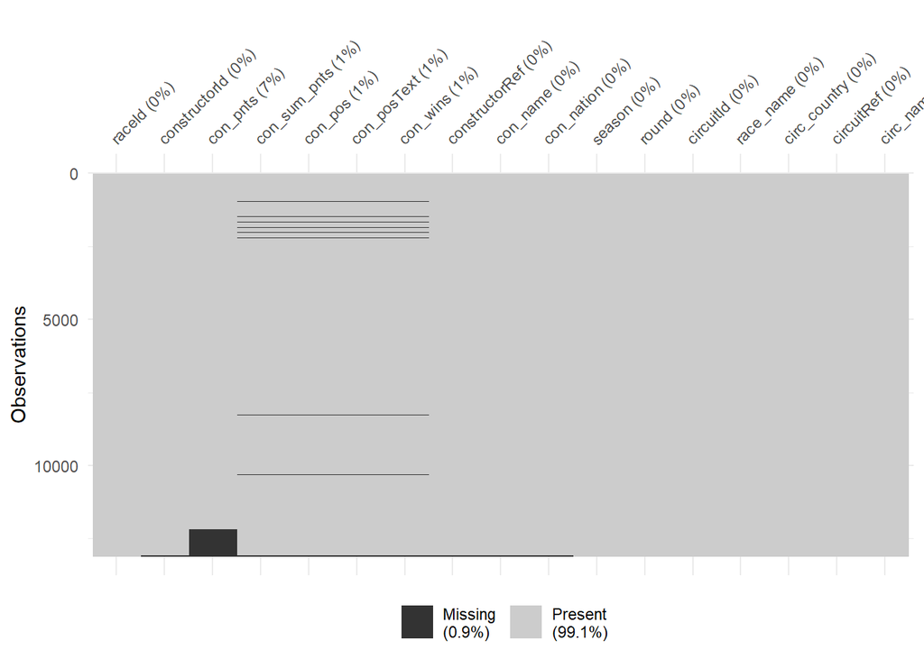

```r
load("C://Users//waliang//Documents//UCSB//third year//pstat 131//eda.rda")

vis_miss(merge_con)
```

Let’s arrange each constructor’s result in order throughout each race season and fill in `con_pnts` and `con_sum_pnts` using each other (since `con_sum_pnts` is an accumulation of `con_pnts` throughout the season).

```r
merge_con1 <- merge_con %>%
  # arrange each constructor's result in order throughout season
  arrange(constructorId, season, raceId, round, con_sum_pnts) %>%
  # replace con_sum_pnts missing values with the actual value using the other con_pnts column
  mutate(con_sum_pnts = case_when((is.na(con_sum_pnts) & season==lag(season) & is.na(con_pnts)!=TRUE) ~ lag(con_sum_pnts)+con_pnts,
                                  (is.na(con_sum_pnts) & season!=lag(season) & is.na(con_pnts)!=TRUE) ~ con_pnts,
                                  is.na(con_sum_pnts)!=TRUE ~ con_sum_pnts))


# vice versa
merge_con2 <- merge_con1 %>%
  arrange(constructorId, season, raceId, round, con_sum_pnts) %>%
  mutate(con_pnts = case_when((is.na(con_pnts) & season==lag(season) & is.na(con_sum_pnts)!=TRUE) ~ con_sum_pnts-lag(con_sum_pnts),
                              (is.na(con_pnts) & season!=lag(season) & is.na(con_sum_pnts)!=TRUE) ~ con_sum_pnts,
                              is.na(con_pnts)!=TRUE ~ con_pnts))

# and again the first direction for good measure
merge_con3 <- merge_con2 %>%
   arrange(constructorId, season, raceId, round, con_sum_pnts) %>%
   mutate(con_sum_pnts = case_when((is.na(con_sum_pnts) & season==lag(season) & is.na(con_pnts)!=TRUE) ~ lag(con_sum_pnts)+con_pnts,
                                   (is.na(con_sum_pnts) & season!=lag(season) & is.na(con_pnts)!=TRUE) ~ con_pnts,
                                   is.na(con_sum_pnts)!=TRUE ~ con_sum_pnts))
```

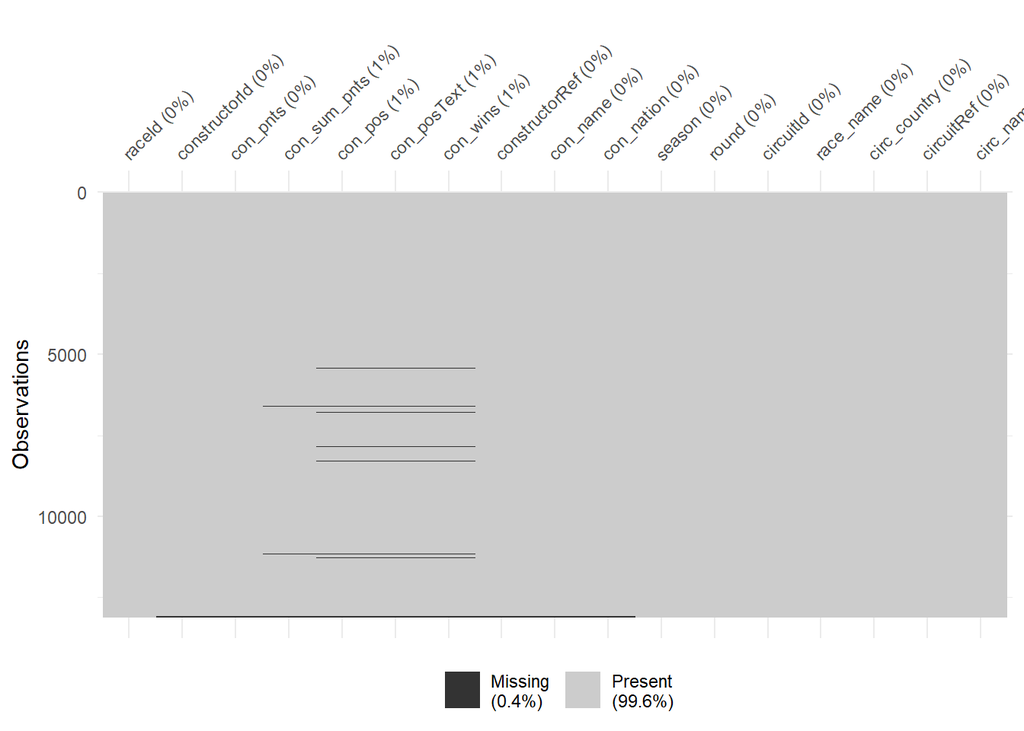

```r
vis_miss(merge_con3)
```

```r
merge_con3$constructorRef <- factor(merge_con3$constructorRef)
```

After fixing `con_pnts` and `con_sum_pnts`, we have a lot less missing data. The missing values in `con_pos`, `con_posText`, and `con_wins` is somewhat minimal. We can deal with these missing values during recipe creation using a linear regression of other variables that measure a constructors progress throughout the race season, like `con_pnts` and `con_sum_pnts`.

Other than this, we don’t have a lot of missing data and the data set is pretty usable.

Now let’s work on `merge_driv` similarly.

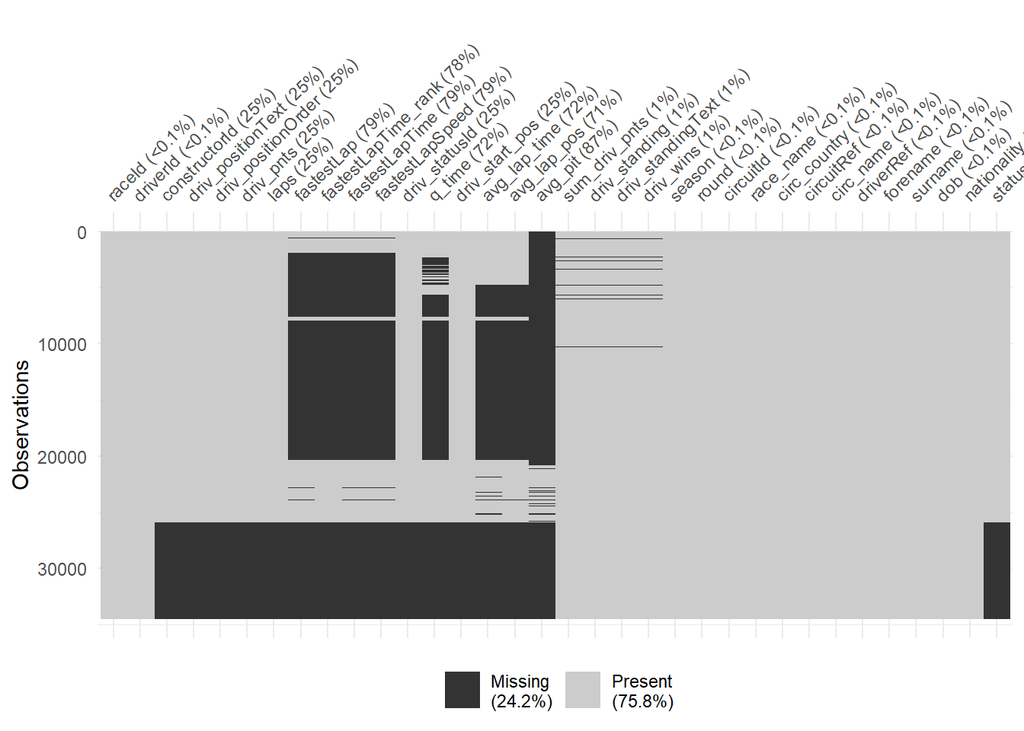

```r
vis_miss(merge_driv, warn_large_data = FALSE)
```

That’s a lot of missing data. There are some drivers with no constructor team! Let’s look at those first.

```r
dim(merge_driv %>%
  filter(is.na(constructorId)))[1]
## [1] 8646
dim(merge_driv)[1]
## [1] 34496
```

There are 8646 out of 34496 observation with missing values from `constructorId` to `avg_pit` and `status`. My guess is that when I was joining data sets that had information available only after a certain year, like `quali`, `pit`, and even `results`, then that conflicted with `driver_standings` that had a lot of data starting from the beginning of F1, leaving empty spots in variables only available after a certain date.

I don’t want to just remove these observations, since they still have data for `driv_standing` and `driv_wins`. Some of the missing variables that I would prefer to have, like `driv_positionOrder`, `driv_pnts`, and `driv_start_pos`, are measures of the success of each driver at each race and throughout the season, similar to `driv_standing` and `driv_wins`. However, I think I will be forced to remove the rows with missing `constructorId` because I will have trouble imputing a categorical variable (`constructorId` is a factor).

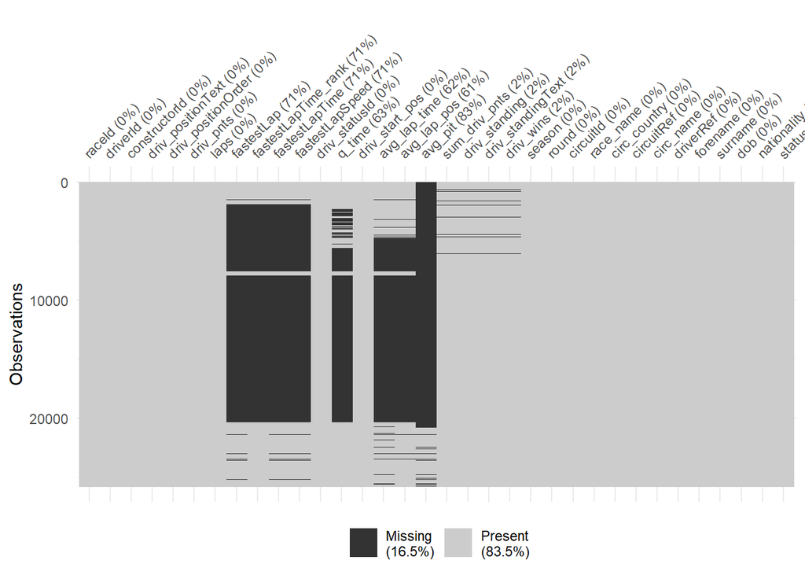

```r
vis_miss(merge_driv1)
```

Deal with missing `driv_standing` and `driv_wins` so we can easily impute the other variables in the recipe later on.

```r
dim(merge_driv1 %>%
      filter(is.na(driv_standing)))[1]
## [1] 469
```

```r
merge_driv2 <- merge_driv1 %>%
  group_by(driverId, round) %>%
  # replace missing driv_standing with the median of the standings the driver gets in that round across seasons
  summarise(driv_standing_na = as.integer(median(driv_standing,na.rm=TRUE)))

merge_driv3 <- full_join(merge_driv1, merge_driv2, by=c("driverId","round"))

merge_driv3 <- merge_driv3 %>%
  mutate(driv_standing =
           case_when(is.na(driv_standing) ~ driv_standing_na,
                     !is.na(driv_standing) ~ driv_standing))
```

```r
dim(merge_driv3 %>%
  filter(is.na(driv_standing)))[1]
## [1] 91
```

By replacing missing `driv_standing` with the median of such in that round number across all seasons, we reduce the missing standing values from 469 to 91. This is a pretty good effort to save some of our data. Then we can omit the 91 missing values.

```r
# omit the rest of missing driv_standing
merge_driv4 <- merge_driv3 %>%
  filter(!is.na(driv_standing))
```

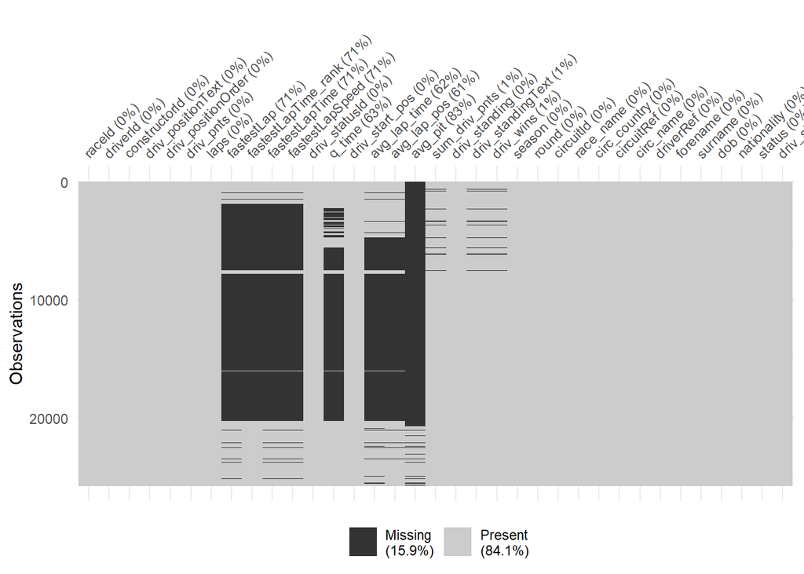

```r
vis_miss(merge_driv4, warn_large_data = FALSE)
```

We can work with this. It’ll get better when imputing during recipe creation.

### Visual EDA

Let’s look at some of the relationships between our variables.

#### Constructor and Driver Points

Let’s take a look at our possible response variables `con_pos` and `driv_pnts`.

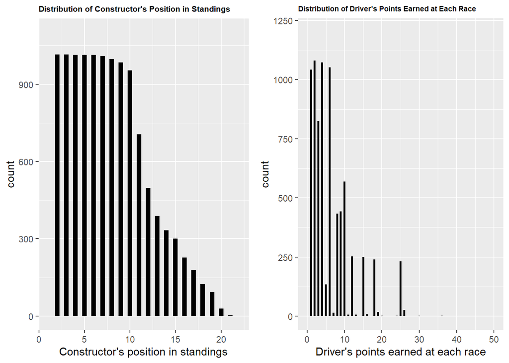

```r
grid.arrange(plot_con, plot_driv, ncol=2)
```

```r
range((merge_con3 %>%
         filter(!is.na(con_pos))
         )$con_pos)
## [1]  1 22

range((merge_con3 %>%
  filter(con_pos==tail(unique(sort((merge_con3 %>%
         filter(!is.na(con_pos))
         )$con_pos)))) %>%
  select(con_pos,con_name, season, race_name, circ_name))$season)
## [1] 1963 1991

range((merge_con3 %>%
  filter(con_pos==tail(unique(sort((merge_con3 %>%
         filter(!is.na(con_pos))
         )$con_pos)))) %>%
  select(con_pos,con_name, season, race_name, circ_name))$season)
## [1] 1963 1991

range((merge_driv4 %>%
         filter(!is.na(driv_pnts))
         )$driv_pnts)
## [1]  0 50
```

The `con_pos` data is from 1 to 22. The constructors with very high positions are pre-2000 (from 1963 to 1991), because now there are only ten constructors each season. The range of `driv_pnts` for the data and possibility is from 0 to 50 (first place at 2014 Abu Dhabi).

* At the 2014 Abu Dhabi Grand Prix, the FIA rewarded double points. So, instead of the usual 25 to 1 point range, first place to tenth place earned 50, 36, 30, 24, 20, 16, 12, 8, 4, and 2 respectively. Understandably, double points was never done again.

#### Correlation Plots

Let’s look at some possible relationships between our variables.

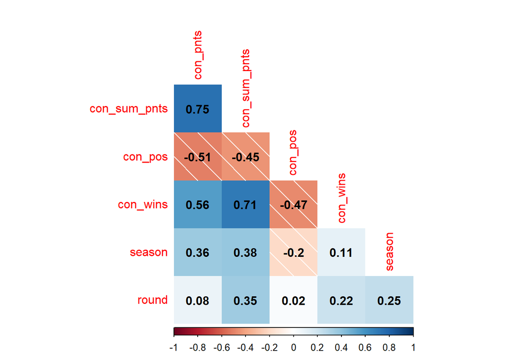

```r
# remove na, identification variables, only numeric
corrplot(cor(merge_con3 %>%
               select_if(is.numeric)%>%
               na.omit()), method="shade", diag=FALSE,addCoef.col=1,number.cex = 1, type="lower")
```

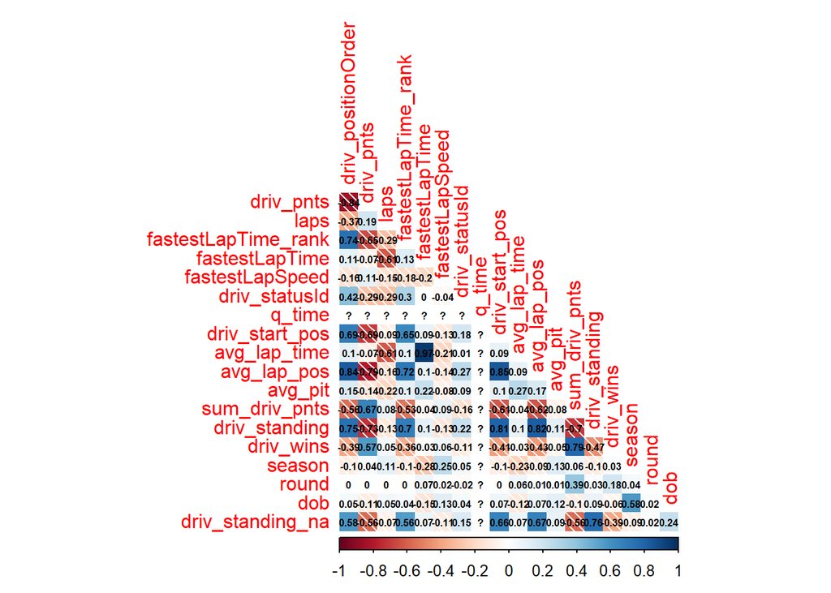

```r
# remove na, q_time has too much na, and identification variables, only numeric
corrplot(cor(merge_driv4 %>%
               select_if(is.numeric) %>%
               na.omit()), method="shade",addCoef.col = 1,number.cex = 0.5, type="lower",diag=FALSE)
```

#### Constructor Position in Standings vs. Constructor Points

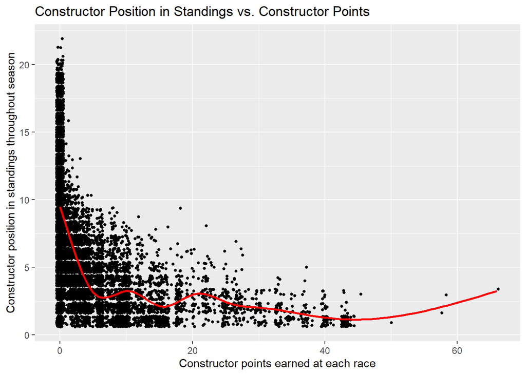

```r
ggplot(merge_con3, aes(x=con_pnts, y=con_pos)) +
  geom_jitter(width=.5, size=1)+
  geom_smooth(col="red", stat="smooth", level=FALSE)+
  labs(title="Constructor Position in Standings vs. Constructor Points", y="Constructor position in standings throughout season", x="Constructor points earned at each race")
```

Understandably so, the lower the points a constructor earns at a race, the more constructors are between your position and the top of the standings. The relationship here also does not seem linear. Once a constructor begins earning points, it is a bit easier to climb positions in the standings, as earning more points for yourself means your competition is earning less points. The trend here looks inverse exponential, but maybe I’m getting ahead of myself.

#### Accumulated Constructor Points vs. Round

Let’s take a closer look at the relationship between `con_sum_pnts` and `round`, something I found interesting as it has to do with the progress and improvement of a constructor team throughout a race season.

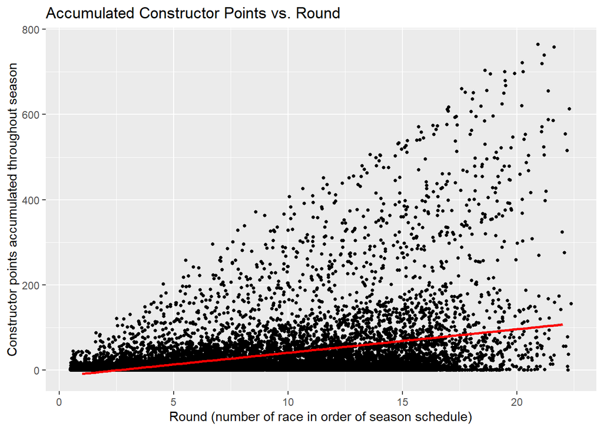

```r
ggplot(merge_con3, aes(x=round, y=con_sum_pnts)) +
  geom_jitter(width=.5, size=1)+
  geom_smooth(method="lm", col="red")+
  labs(title="Accumulated Constructor Points vs. Round", y="Constructor points accumulated throughout season", x="Round (number of race in order of season schedule)")
```

It is interesting to see the majority of points to be somewhat plateauing in `con_sum_pnts` as `round` increases. You can also see the behavior of the handful of championship winning constructor teams that manage to have a steady increase in their accumulated points.

#### Driver Points vs. Average Lap Position

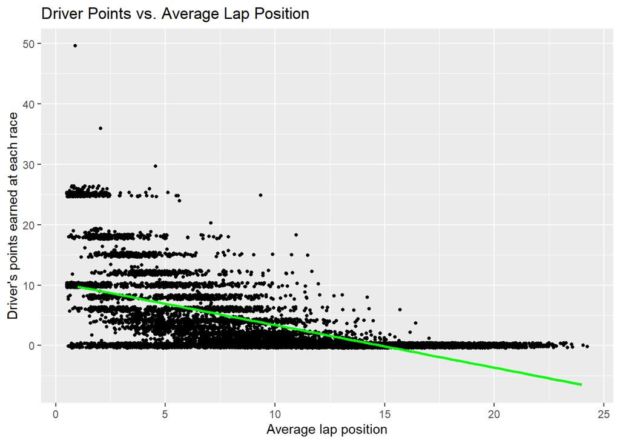

```r
ggplot(merge_driv4, aes(x=avg_lap_pos, y=driv_pnts)) +
  geom_jitter(width=.5, size=1)+
  geom_smooth(method="lm", col="green")+
  labs(title="Driver Points vs. Average Lap Position", x="Average lap position", y="Driver's points earned at each race")
```

We can see that the back-markers, i.e. the drivers that happened to spend most of their race at I would say positions fifteen and greater, have very little chance with earning points. Most of the drivers with average lap position of fifteen and greater are lined up at zero points earned. Reasons drivers spend most of their time out of the points can vary from lacking race pace, having issues with the car, to poor tyre management, which are all valid reasons that keep them from making moves and overtaking to get into the points.

What’s also interesting is that that thick pile of zero point earners extends all the way to the higher positions. It is not a shock for drivers who are consistently in top positions, even race leaders, to suddenly encounter a car failure and DNF from the race. It is totally possible and is part of the charm of F1.

#### Average Lap Position vs. Driver Start Position

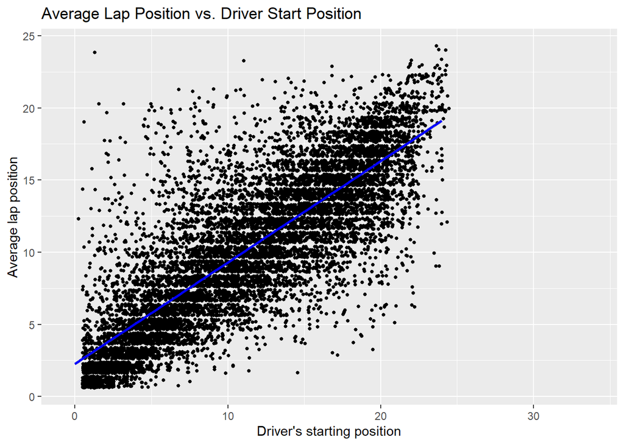

```r
ggplot(merge_driv4, aes(x=driv_start_pos, y=avg_lap_pos)) +
  geom_jitter(width=.5, size=1)+
  geom_smooth(method="lm", col="blue")+
  labs(title="Average Lap Position vs. Driver Start Position", x="Driver's starting position", y="Average lap position")
```

Like the correlation plot suggested, we have a clear positive relationship between average lap position and driver start position. Since, qualifying sessions determine driver start position, this also supports the idea that qualifying and sprint qualifying have incredible influence on the course of a race.

## Model Set-Up

**Code in file model_building.rda**

Now we can start fitting models to see if we can predict `con_pos` and `driv_pnts`.

### Data Split

We will be splitting our data sets into a training set and testing set. A majority of the data should be in the training set, which is what we build our model off of. Having separate training and testing sets allows us to see a truer test of how well our model performs. We need to test our model on data it has not been trained on to obtain a realistic idea of where our model is at. This also avoids over-fitting. If we were to test our model on data its been trained on, the results will be very accurate, but falsely so because it is not a true prediction at that point. Our testing data should be akin to a blind taste test for our model, but we build the model’s connections and understandings of how to determine what it will be tasting.

We will split our data so that 70% of it goes to training and 30% of it is testing. We also stratify on the outcome variables `con_pos` and `driv_pnts` to make sure our data is split with an equal distribution of the response variables in our training and testing data.

```r
# split into training and testing, strata on response variables
con_split <- initial_split(merge_con3, prop = 0.7, strata = con_pos)
con_train <- training(con_split)
con_test <- testing(con_split)

driv_split <- initial_split(merge_driv4, prop = 0.7, strata =driv_pnts)
driv_train <- training(driv_split)
driv_test <- testing(driv_split)

# check split proportions
nrow(con_train)/nrow(merge_con3)
nrow(con_test)/nrow(merge_con3)
nrow(driv_train)/nrow(merge_driv4)
nrow(driv_test)/nrow(merge_driv4)
```

### Recipe

We have to decide on a recipe, or formula, made up of our response variable and predictors, that can be used for many types of models later. From our `merge_con3` data set, we are using `con_pos` as a response variable. I want to include measures of points, home races (nationality), race order, year, and the specific circuit/track have influence on `con_pos`. So, for predictors, I have decided on: `constructorRef`, `con_pnts`, `con_wins`, `con_nation`, `season`, `round`, `circuitRef`, and `circ_country`.

For `merge_driv`, our response variable is `driv_pnts`. For predictors, I want to include: `driverRef`, `constructorRef`, `driv_positionText`, `driv_positionOrder`, `laps`, `fastestLapTime_rank`, `fastestLapSpeed`, `driv_start_pos`, `avg_lap_time`, `avg_lap_pos`, `driv_standing`, `driv_wins`, `season`, `round`, `circuitRef`, `circ_country`, `dob`, `nationality`, and `status`.

I made sure to include only one of `pnts` or `sum_pnts` variables because they are calculated dependently. Same thing with `fastestLapTime_rank` and `fastestLap` since one variable is a ranking of the other. Since `driv_start_pos` is inherently a result of qualifying sessions, I feel that `q_time` is less useful. Especially since `q_time` is a decimal amount of seconds and is more missing than not, I think excluding `q_time` is preferred.

```r
# omit the small amount of missing values left
merge_con3 <- merge_con3 %>%
  na.omit()


# CONSTRUCTOR RECIPE
con_rec <-
  recipe(con_pos ~ constructorRef+con_pnts+con_wins+con_nation+season+
           round+circuitRef+circ_country, data = con_train) %>%

  # omit the small amount of missing values left
  step_naomit(all_predictors())%>%

  # there are a hundreds of different constructors and circuits, so we need to collapse the less common ones into an other category
  step_other(constructorRef, threshold=.1) %>%
  step_other(con_nation, threshold=.1) %>%
  step_other(circuitRef, threshold=.1) %>%
  step_other(circ_country, threshold=.1) %>%
  step_naomit()%>%


  # dummy code categorical variables
  step_dummy(all_nominal_predictors()) %>%

  # remove variables (likely the dummy coded ones) that only contain a single value
  step_zv(all_predictors())%>%
  # step_novel(all_nominal_predictors())%>%
  # step_unknown(all_nominal_predictors())%>%

  # normalizing
  step_center(all_predictors()) %>%
  step_scale(all_predictors())


# prep and bake
prep(con_rec) %>%
  bake(new_data = con_train)
```

### K-fold Cross Validation

We will also use k-fold cross validation. K-fold cross-validation is a process of setting aside a portion of the training data to split into “k folds” or k number of sections, which within each k fold takes a turn in acting as the validation set while the rest of the k folds are training data. This is done in a manner so that each k times we train and assess, each training set and validation set is mutually exclusive. So, the process should be fitting, then assessing k times, before one final assessment on the actual testing split portion of data. Let’s do 10 folds.

```r
con_folds <- vfold_cv(con_train, v = 10)

con_folds2 <- vfold_cv(con_train, v = 5)
# for random forest for the sake of time
```

## Model Building

At this point I decided to only work on the constructor data set for the sake of time.

Our process for building our models follows the same steps. The process is as follows:

1. set up model with tuning parameters, the engine, and mode (either regression or classification)

```r
# LINEAR MODEL
lm_model<- linear_reg(engine="lm")


# POLYNOMIAL REGRESSION
# tune degree on the numerical variables (degree on these variables will amplify their effect)
      # ex. a change in points and wins will affect constructor position more than normal
con_polyrec <- con_rec %>%
  step_poly(con_pnts,con_wins,season,round,degree=tune())

poly_model <- linear_reg(mode="regression",
                         engine="lm")


# K NEAREST NEIGHBORS
# tune neighbors
knn_model <- nearest_neighbor(neighbors = tune(),
                              mode="regression",
                              engine="kknn")


# ELASTIC NET LINEAR REGRESSION
# tune penalty and mixture
en_model <- linear_reg(mixture=tune(),
                       penalty=tune(),
                       mode="regression",
                       engine="glmnet")


# ELASTIC NET W/ LASSO
# tune penalty, set mixture to 1 for lasso penalty
en_lasso <- linear_reg(penalty=tune(),
                       mixture=1,
                       mode="regression",
                       engine="glmnet")


# ELASTIC NET W/ RIDGE
# tune penalty, set mixture to 0 for ridge penalty
en_ridge <- linear_reg(penalty=tune(),
                       mixture=0,
                       mode="regression",
                       engine="glmnet")


# RANDOM FOREST
# tune number of predictors (mtry), trees, and minimum number of values in each node (min_n)
rf_model <- rand_forest(mtry = tune(),
                           trees = tune(),
                           min_n = tune()) %>%
  set_engine("ranger", importance = "impurity") %>%
  set_mode("regression")
```

2. set up work flow with model and recipe

```r
# LINEAR MODEL
con_lmwflow <- workflow() %>%
  add_model(lm_model) %>%
  add_recipe(con_rec)



# POLYNOMIAL REGRESSION
con_polywflow <- workflow() %>%
  add_model(poly_model) %>%
  add_recipe(con_polyrec)


# K NEAREST NEIGHBORS
con_knnwflow <- workflow() %>%
  add_model(knn_model) %>%
  add_recipe(con_rec)


# ELASTIC NET LINEAR REGRESSION
con_enwflow <- workflow() %>%
  add_model(en_model) %>%
  add_recipe(con_rec)



# ELASTIC NET W/ LASSO
con_lassowflow <- workflow() %>%
  add_model(en_lasso) %>%
  add_recipe(con_rec)


# ELASTIC NET W/ RIDGE
con_ridgewflow <- workflow() %>%
  add_model(en_ridge) %>%
  add_recipe(con_rec)



# RANDOM FOREST
con_rfwflow <- workflow() %>%
  add_model(rf_model) %>%
  add_recipe(con_rec)
```

3. set up tuning grid with ranges and levels for the tuning of parameters

```r
# POLYNOMIAL REGRESSION
# range degree from 1 to 5
poly_grid <- grid_regular(degree(range=c(1,5)),
                        levels=5)

# K NEAREST NEIGHBORS
# range neighbors from 1 to 15
knn_grid <- grid_regular(neighbors(range=c(1,15)),
                        levels=5)


# ELASTIC NET LINEAR REGRESSION
en_grid <- grid_regular(penalty(range=c(0.01,3), trans=identity_trans()),
                        mixture(range=c(0,1)),
                        levels=10)


# ELASTIC NET W/ LASSO and
# ELASTIC NET W/ RIDGE
lasso_ridge_grid <- grid_regular(penalty(range=c(0.01,3),
                                         trans=identity_trans()), levels=10)


# RANDOM FOREST
# predictors (mtry) range depend on the recipe
con_rfgrid <- grid_regular(mtry(range=c(1,9)),
                        trees(range=c(200,400)),
                        min_n(range=c(10,20)),
                        levels=5)
```

4. tune model using workflow with k-fold cross validation, and tuning grid

```r
# POLYNOMIAL REGRESSION
con_polytune <- tune_grid(
  con_polywflow,
  resamples = con_folds,
  grid = poly_grid)



# K NEAREST NEIGHBORS
con_knntune <- tune_grid(
    con_knnwflow,
    resamples = con_folds,
    grid = knn_grid)



# ELASTIC NET
con_entune <- tune_grid(
  con_enwflow,
  resamples = con_folds,
  grid = en_grid)


# RIDGE REGRESSION
con_ridgetune <- tune_grid(
  con_ridgewflow,
  resamples = con_folds,
  grid = lasso_ridge_grid)



# LASSO REGRESSION
con_lassotune <- tune_grid(
  con_lassowflow,
  resamples = con_folds,
  grid = lasso_ridge_grid)


# RANDOM FOREST
con_rftune <- tune_grid(
  con_rfwflow,
  resamples = con_folds2,
  grid = con_rfgrid)
```

5. Collect metrics of tuned models. We want to minimize **root mean squared error (RMSE)**, so find the lowest RMSE for each tuned model.

```r
load("C://Users//waliang//Documents//UCSB//third year//pstat 131//model_building_final.rda")

load("C://Users//waliang//Documents//UCSB//third year//pstat 131//model_results_final.rda")
```

```r
lm_rmse <- collect_metrics(con_lmfit) %>%
  slice(1)

ridge_rmse <- collect_metrics(con_ridgetune) %>%
  arrange(mean) %>%
  filter(.metric=="rmse") %>%
  slice(1)

# LASSO REGRESSION
lasso_rmse <- collect_metrics(con_lassotune) %>%
  arrange(mean) %>%
  filter(.metric=="rmse") %>%
  slice(1)

# POLYNOMIAL REGRESSION
poly_rmse <- collect_metrics(con_polytune) %>%
  arrange(mean) %>%
  filter(.metric=="rmse") %>%
  slice(1)

# K NEAREST NEIGHBORS
knn_rmse <- collect_metrics(con_knntune) %>%
  arrange(mean) %>%
  filter(.metric=="rmse") %>%
  slice(1)

# ELASTIC NET
elastic_rmse <- collect_metrics(con_entune) %>%
  arrange(mean)%>%
  filter(.metric=="rmse") %>%
  slice(1)
```

```r
lm_rmse
## # A tibble: 1 x 6
##   .metric .estimator  mean     n std_err .config
##   <chr>   <chr>      <dbl> <int>   <dbl> <chr>
## 1 rmse    standard    3.45    10  0.0155 Preprocessor1_Model1
ridge_rmse
## # A tibble: 1 x 7
##   penalty .metric .estimator  mean     n std_err .config
##     <dbl> <chr>   <chr>      <dbl> <int>   <dbl> <chr>
## 1    0.01 rmse    standard    3.45    10  0.0157 Preprocessor1_Model01
lasso_rmse
## # A tibble: 1 x 7
##   penalty .metric .estimator  mean     n std_err .config
##     <dbl> <chr>   <chr>      <dbl> <int>   <dbl> <chr>
## 1    0.01 rmse    standard    3.45    10  0.0157 Preprocessor1_Model01
poly_rmse
## # A tibble: 1 x 7
##   degree .metric .estimator  mean     n std_err .config
##    <dbl> <chr>   <chr>      <dbl> <int>   <dbl> <chr>
## 1      5 rmse    standard    2.82    10  0.0264 Preprocessor5_Model1
knn_rmse
## # A tibble: 1 x 7
##   neighbors .metric .estimator  mean     n std_err .config
##       <int> <chr>   <chr>      <dbl> <int>   <dbl> <chr>
## 1        15 rmse    standard    2.65    10  0.0212 Preprocessor1_Model5
elastic_rmse
## # A tibble: 1 x 8
##   penalty mixture .metric .estimator  mean     n std_err .config
##     <dbl>   <dbl> <chr>   <chr>      <dbl> <int>   <dbl> <chr>
## 1    0.01       1 rmse    standard    3.45    10  0.0157 Preprocessor1_Model091
rf_rmse
## # A tibble: 1 x 9
##    mtry trees min_n .metric .estimator  mean     n std_err .config
##   <int> <int> <int> <chr>   <chr>      <dbl> <int>   <dbl> <chr>
## 1     4   350    20 rmse    standard    2.37     5  0.0162 Preprocessor1_Model1~
```

## Model Results

**Code in file model_results.rda**

Let’s compare the models from before that minimize RMSE to find best performing one out of them all.

### Elastic Net

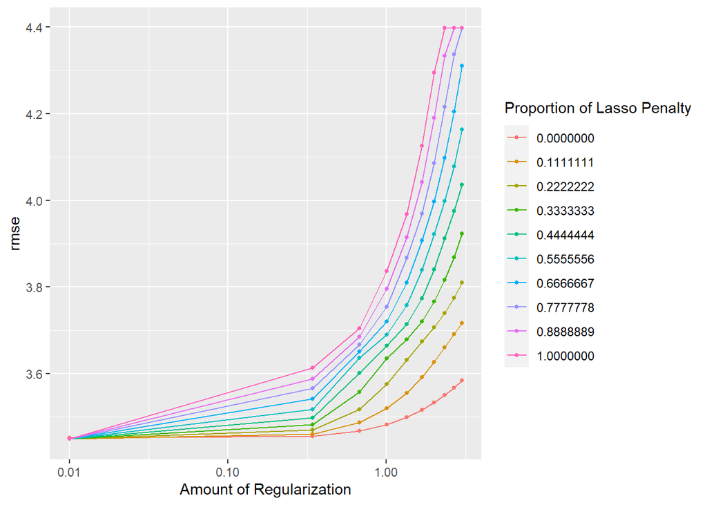

```r
autoplot(con_entune, metric="rmse")
```

### Polynomial Regression

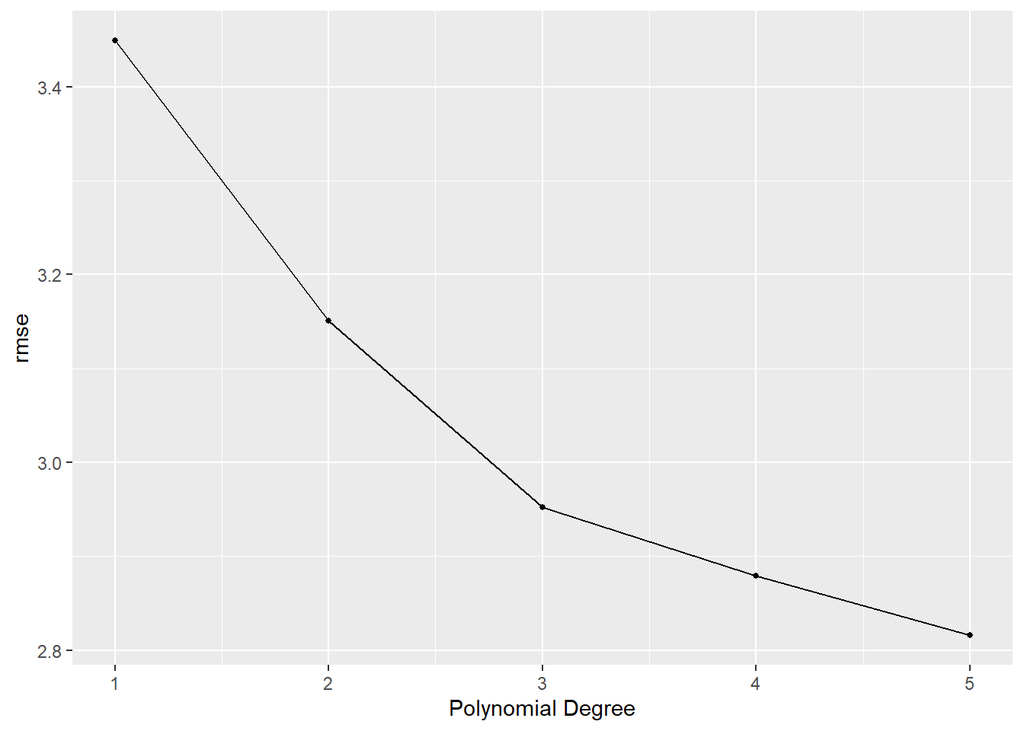

```r
autoplot(con_polytune, metric="rmse")
```

As the degree of our continuous variables increase from 1 to 5, the RMSE decreases steadily. This aligned with my expectations because our actual data, like `con_pnts` and `con_wins`, are based on singular points and wins where small amounts can make a difference in determining a constructor’s place in the standings. Often times, a constructor’s position in the standings will only be guaranteed a the last race, because competition between competitors will last the entire season. So, by adding degrees, we are amplifying the differences between our data points. Thus, the effect of each predictor will become more and more influential. It seems a degree of 5 would perform the best, but I can also assume that an even higher degree would lower the RMSE even more.

### K-Nearest Neighbors

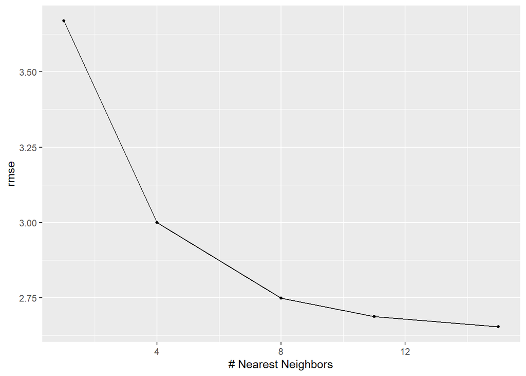

```r
autoplot(con_knntune, metric="rmse")
```